# ME2055 HW 6

## Jorgen Wu

### April 29th 2026

```python
import matplotlib.pyplot as plt
import numpy as np
```

# Problem Statement

Consider the following 1-D hyperbolic PDE: \begin{split} \frac{\partial u}{\partial t} + c \frac{\partial u}{\partial x} = 0 \end{split}

The following initial condition is used, along with periodic boundary conditions.

```
Simulation CFL number is 0.80
```

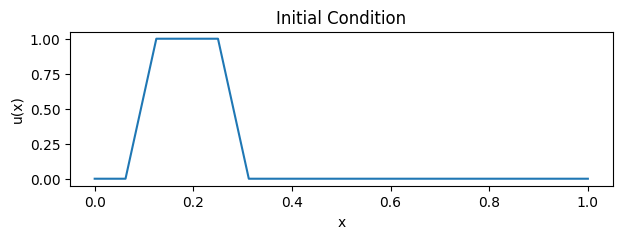

```python
C = 1
L = 1
NX = 161
dx = L / (NX - 1)
xarr = np.linspace(0, 1, NX)

T = 1.0
NT = 201
Tarr = np.linspace(0, 1, NT)
dt = Tarr[1]

CFL = C * dt / dx
print(f"Simulation CFL number is {CFL:.2f}")

u0 = np.zeros_like(xarr)
u0[NX//16:NX//8] = [16 * dx * i for i in range(NX//16)]
u0[NX//8:NX//4] = C
u0[NX//4:NX//4+NX//16] = [1 - 16 * dx * i for i in range(NX//16)]

plt.figure(figsize=(7, 2))
plt.plot(xarr, u0)
plt.xlabel("x")
plt.ylabel("u(x)")
plt.title("Initial Condition")
```

# 1: FTCS

For a finite difference method that is Forward in Time and Central in Space (FTCS), the PDE is discretized as: \begin{split} \frac{u_l^{n+1} - u_l^n}{\Delta t} + c \frac{u_{l+1}^n - u_{l-1}^n}{2\Delta x} = 0 \end{split} which results in the following: \begin{split} u_l^{n+1} = u_l^n + \Delta t \bigg( -c \frac{u_{l+1}^n - u_{l-1}^n}{2\Delta x} \bigg) \end{split}

## Stability Analysis

Assuming a solution of form $u_l^n = A_n e^{ikx_l}$: \begin{split} A_{n+1}e^{ikx_l} = A_ne^{ikx_l} + \Delta t \bigg( -c \frac{A_n e^{ik(x_l + \Delta x)} - A_n e^{ik(x_l - \Delta x)}}{2\Delta x} \bigg) \end{split} Divide out $e^{ikx_l}$: \begin{split} A_{n+1} = A_n - \frac{c \Delta t}{2\Delta x} A_n \big( e^{ik\Delta x} - e^{-ik\Delta x} \big) \end{split}

Using the follow expansions (from Euler's identity): \begin{split} e^{ik\Delta x} &= \cos(k\Delta x) + i \sin(k\Delta x) \\ e^{-ik\Delta x} &= \cos(k\Delta x) - i \sin(k\Delta x) \end{split}

The following is obtained: \begin{split} \frac{A_{n+1}}{A_n} = 1 - \frac{c\Delta t}{\Delta x}i\sin(k\Delta x) \end{split}

The magnitude of the amplification factor is $1 + (\frac{c \Delta t}{\Delta x})^2\sin^2(k\Delta x)$, which is always greater than 1. So, this method is unconditionally unstable.

## Modified Equation Analysis

Since this method is first order in time and second order in space, the following expansions of each term will be used: \begin{split} u_l^n &= u \\ u_l^{n+1} &= u + \Delta t u_t + \frac{\Delta t^2}{2}u_{tt} + \cdots \\ u_{l+1}^n &= u + \Delta x u_x + \frac{\Delta x^2}{2}u_{xx} + \frac{\Delta x^3}{6}u_{xxx} + \cdots \\ u_{l-1}^n &= u - \Delta x u_x + \frac{\Delta x^2}{2}u_{xx} - \frac{\Delta x^3}{6}u_{xxx} + \cdots \\ \end{split}

Plugging these into the discretized PDE: \begin{split} \frac{\Delta t u_t + \frac{\Delta t^2}{2}u_{tt}}{\Delta t} + \frac{c}{2\Delta x}\bigg(2\Delta x u_x + \frac{\Delta x3}{3}u_{xxx} \bigg) &= 0 \end{split}

\begin{split}\downarrow\end{split}

\begin{split} u_t + \frac{\Delta t}{2}u_{tt} + c\bigg(u_x + \frac{\Delta x^2}{6}u_{xxx}\bigg)=0 \end{split}

To get rid of the double time derivative, use the following: $u_t=-cu_x$, so $u_{tt} = -cu_{xt} = -c(u_t)_x = -c(-cu_x)_x = c^2u_{xx}$. So: \begin{split} u_t + cu_x = -\frac{c^2\Delta t}{2}u_{xx} - \frac{c \Delta x^2}{6}u_{xxx} \end{split}

The diffusion coefficient of $-\frac{c^2\Delta t}{2}$ indicates the equation is actually *anti-diffusive*, which explains why this method is unconditionally unstable.

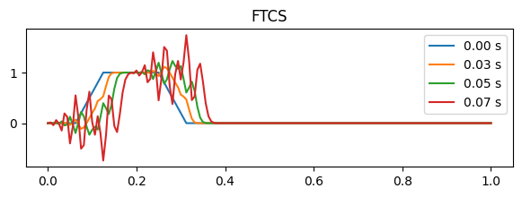

```python
solution_FTCS = np.zeros((NX, NT))
solution_FTCS[:, 0] = u0

for tdx in range(NT - 1):
    for xdx in range(NX):
        lp1 = (xdx + 1) % NX
        lm1 = (xdx - 1) % NX
        solution_FTCS[xdx, tdx+1] = (
            solution_FTCS[xdx, tdx]
            + dt * (-C * (solution_FTCS[lp1, tdx] - solution_FTCS[lm1, tdx])/(2*dx))
        )

plt.figure(figsize=(7,2))
for tdx in [0, 5, 10, 15]:
    plt.plot(xarr, solution_FTCS[:, tdx], label=f"{Tarr[tdx]:.2f} s")
plt.legend()
plt.title("FTCS")
```

# 2: Implicit in Time, Central in Space

For a finite difference method that is Backwards in Time and Central in Space (BTCS?), the PDE is discretized as: \begin{split} \frac{u_l^n - u_l^{n-1}}{\Delta t} + c \frac{u_{l+1}^n - u_{l-1}^n}{2\Delta x} = 0 \end{split}

## Stability Analysis

Assuming a solution of form $u_l^n = A_n e^{ikx_l}$: \begin{split} \frac{A_n-A_{n-1}}{\Delta t} + c \frac{A_ne^{ik\Delta x} - A_ne^{-ik\Delta x}}{2\Delta x} = 0 \end{split}

\begin{split}\downarrow\end{split}

\begin{split} A_n = A_{n-1} - \frac{c\Delta t}{2\Delta x} A_n (e^{ik\Delta x} - e^{-ik\Delta x}) \end{split}

\begin{split}\downarrow\end{split}

\begin{split} 1 = \frac{A_{n-1}}{A_n} + \frac{c\Delta t}{\Delta x}i\sin(k\Delta x) \end{split}

With some rearranging: \begin{split} \frac{A_n}{A_{n-1}} = \frac{1}{1 - \frac{c\Delta t}{\Delta x}i\sin(k\Delta x)} \end{split}

The denominator of this expression has a minimum magnitude of 1 and is otherwise greater than 1, so the amplification factor is always less than 1. This indicates that the numerical method is unconditionally stable.

## Modified Equation Analysis

In addition to the expansions shown in the FTCS result, the following expansion is used to go backwards in time: \begin{split} u_l^{n-1} &= u - \Delta t u_t + \frac{\Delta t^2}{2}u_{tt} + \cdots \\ \end{split}

The discretized PDE is then: \begin{split} \frac{\Delta t u_t - \frac{\Delta t^2}{2}u_{tt}}{\Delta t} + c \frac{2\Delta x u_x + \frac{\Delta x^3}{3}u_{xxx}}{2\Delta x}=0 \end{split}

Again, $u_{tt} = c^2u_{xx}$.

\begin{split} u_t + cu_x = \frac{\Delta t}{2}u_{tt} - \frac{c\Delta x^2}{6}u_{xxx} \\ \end{split}

\begin{split}\downarrow\end{split}

\begin{split} u_t + cu_x = \frac{c^2 \Delta t}{2}u_{xx} - \frac{c\Delta x^2}{6}u_{xxx} \end{split}

The numerical diffusion coefficient is $\frac{c^2 \Delta t}{2}$, which is positive and thus diffusive unlike for the FTCS scheme. The numerical dispersion coefficient is $\frac{c\Delta x^2}{6}$.

This unconditional stability can be demonstrated numerically. Note that the implicit timestep requires solution of a linear system. The method of successive over-relaxation (SOR) will be used to solve this system.

In the solution, the diffusive effect of the numerical method can be observed - despite the original PDE having no diffusion or viscous term, the solution shows smearing.

```python
def solverSOR(A, b, relax = 1.0, maxitr: int = 10000, tol: float = 1e-7):
    M, N = A.shape
    x = np.zeros_like(b, dtype=float)
    for itr in range(maxitr):
        x_prev = x.copy()
        for j in range(N):
            new_value = (b[j] - np.dot(A[j, :j], x[:j]) - np.dot(A[j, j+1:], x[j+1:])) / A[j, j]
            x[j] = new_value * relax + (1 - relax) * x[j]
        if np.max(np.abs(x - x_prev)) < tol:
            # print(f"Converged in {itr + 1} iterations")
            break
    else:
        print(f"Warning: did not converge within {maxitr} iterations")
    return x
```

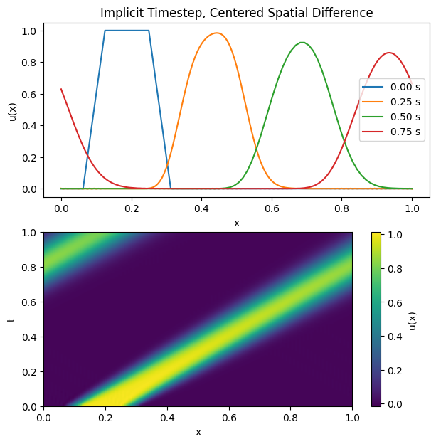

```python
solution_BTCS = np.zeros((NX, NT))
solution_BTCS[:, 0] = u0

A = np.zeros((NX, NX))
b = np.zeros(NX)
for tdx in range(1, NT):
    # build coefficient matrix
    for xdx in range(NX):
        lp1 = (xdx + 1) % NX
        lm1 = (xdx - 1) % NX
        A[xdx, lm1] = -C / (2 * dx)
        A[xdx, xdx] = 1 / dt
        A[xdx, lp1] = C / (2 * dx)
        b[xdx] = solution_BTCS[xdx, tdx-1] / dt
    solution_BTCS[:, tdx] = solverSOR(A, b, relax=0.5)

plt.figure(figsize=(7, 7))

plt.subplot(2, 1, 1)
for tdx in [0, 50, 100, 150]:
    plt.plot(xarr, solution_BTCS[:, tdx], label=f"{Tarr[tdx]:.2f} s")
plt.legend()
plt.xlabel("x")
plt.ylabel("u(x)")
plt.title("Implicit Timestep, Centered Spatial Difference")

plt.subplot(2, 1, 2)
plt.imshow(solution_BTCS.T, origin="lower", aspect="auto", extent=(0, L, 0, T))
plt.colorbar(label="u(x)")
plt.xlabel("x")
plt.ylabel("t")
```

# 3: First-order Upwinding

Assuming $c>0$, then the discretization is: \begin{split} \frac{u_l^{n+1}-u_l^n}{\Delta t} + c \frac{u_{l}^n-u_{l-1}^n}{\Delta x} = 0 \end{split}

## Stability Analysis

Assuming a solution of form $u_l^n = A_n e^{ikx_l}$: \begin{split} \frac{A_{n+1}e^{ik\Delta x} - A_ne^{ik\Delta x}}{\Delta t} + c \frac{A_ne^{ikx_l} - A_ne^{ik(x_l-\Delta x)}}{\Delta x} = 0 \end{split}

Divide out the exponential term and group terms:

\begin{split} A_{n+1} = A_n - \frac{c\Delta t}{\Delta x} A_n (1 - e^{-ik\Delta x}) = 0 \end{split}

Using $e^{-ik\Delta x} = \cos(k\Delta x) - i\sin(k\Delta x)$: \begin{split} \frac{A_{n+1}}{A_n} = 1 - \frac{c\Delta t}{\Delta x} + \frac{c\Delta t}{\Delta x}\cos(k\Delta x) - \frac{c\Delta t}{\Delta x}i\sin(k\Delta x) \end{split}

The amplification ratio can then be found as follows. For brevity, let $\frac{c\Delta t}{\Delta x} \equiv CFL$.

\begin{split} |G|^2 &= (1 - CFL + CFL \cos(k\Delta x))^2 + CFL^2 \sin^2(k\Delta x) \\ &= (1-CFL)^2 + 2(1-CFL)CFL\cos(k\Delta x) + CFL^2 \cos^2(k\Delta x) + CFL^2 \sin^2(k\Delta x) \\ &= 1 - 2CFL + CFL^2 + 2(CFL - CFL^2)\cos(k\Delta x) + CFL^2 \\ &= 1 - 2CFL + 2CFL^2 + 2(CFL - CFL^2)\cos(k\Delta x) \\ &= 1 - 2CFL(1-CFL)(1-\cos(k\Delta x)) \end{split}

Note that $(1-\cos(k\Delta x)) \geq 0 \space \forall \space x$. So, for the amplification ratio to be less than 1, we need $(1-CFL) \geq 0$. This gives us the stability criterion of $CFL \leq 1$, or $\frac{c \Delta t}{\Delta x} \leq 1$.

## Modified Equation Analysis

The same expansion terms as previously described are used again.

Plugging into the discretized upwind PDE, the modified equation is then: \begin{split} \frac{\Delta t u_t + \frac{\Delta t^2}{2}u_{tt}}{\Delta t} + c \frac{\Delta x u_x - \frac{\Delta x^2}{2}u_{xx} + \frac{\Delta x^3}{6}u_{xxx}}{\Delta x} = 0 \end{split}

\begin{split}\downarrow\end{split}

\begin{split} u_t + \frac{\Delta t}{2}u_{tt} + c \big(u_x - \frac{\Delta x}{2}u_{xx} + \frac{\Delta x^2}{6}u_{xxx}\big) = 0 \end{split}

Collecting terms, and using $u_{tt}=c^2u_{xx}$, we get: \begin{split} u_t + cu_x = \bigg(\frac{c\Delta x}{2} - \frac{c^2 \Delta t}{2}\bigg) u_{xx} - \frac{c \Delta x^2}{6}u_{xxx} \end{split}

The numerical diffusion coefficient is $\big(\frac{c\Delta x}{2} - \frac{c^2 \Delta t}{2}\big)$ and the numerical dispersion coefficient is $-\frac{c \Delta x^2}{6}$.

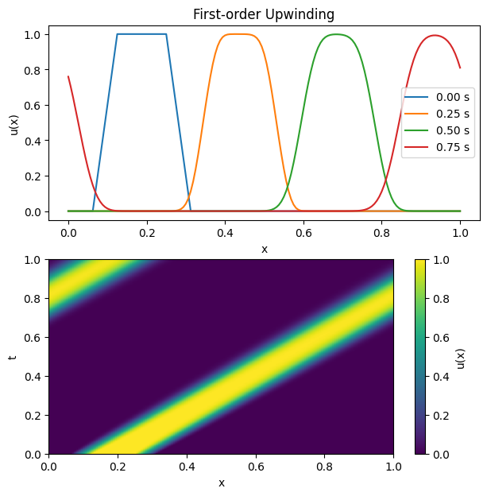

```python
solution_upwind = np.zeros((NX, NT))
solution_upwind[:, 0] = u0

for tdx in range(0, NT-1):
    for xdx in range(NX):
        lm1 = (xdx - 1) % NX
        solution_upwind[xdx, tdx+1] = (
            solution_upwind[xdx, tdx]
            + dt * (-C * (solution_upwind[xdx, tdx] - solution_upwind[lm1, tdx])/dx)
        )

plt.figure(figsize=(7, 7))

plt.subplot(2, 1, 1)
for tdx in [0, 50, 100, 150]:
    plt.plot(xarr, solution_upwind[:, tdx], label=f"{Tarr[tdx]:.2f} s")
plt.legend()
plt.xlabel("x")
plt.ylabel("u(x)")
plt.title("First-order Upwinding")

plt.subplot(2, 1, 2)
plt.imshow(solution_upwind.T, origin="lower", aspect="auto", extent=(0, L, 0, T))
plt.colorbar(label="u(x)")
plt.xlabel("x")
plt.ylabel("t")
```

# 4: Lax-Friedrichs

The discretized PDE is: \begin{split} \frac{u_l^{n+1} - \frac{1}{2}(u_{l+1}^n + u_{l+1}^n)}{\Delta t} + c \frac{u_{l+1}^n - u_{l+1}^n}{2\Delta x} = 0 \end{split}

## Stability Analysis

Assuming a solution of form $u_l^n = A_n e^{ikx_l}$: \begin{split} \frac{A_{n+1}e^{ik\Delta x} - \frac{1}{2}(A_ne^{ik(x+\Delta x)} + A_ne^{ik(x-\Delta x)})}{\Delta t} + c \frac{A_ne^{ik(x+\Delta x)} - A_ne^{ik(x-\Delta x)}}{2\Delta x} = 0 \end{split}

\begin{split}\downarrow\end{split}

\begin{split} A_{n+1} = \frac{1}{2}\big( A_n e^{ik\Delta x} + A_n e^{-ik\Delta x} \big) + \frac{c\Delta t}{2\Delta x} \big( A_ne^{ik\Delta x} - A_ne^{-ik\Delta x} \big) = 0 \end{split}

\begin{split}\downarrow\end{split}

\begin{split} \frac{A_{n+1}}{A_n} = \frac{1}{2}\big( e^{ik\Delta x} + e^{-ik\Delta x} \big) + \frac{c\Delta t}{2\Delta x} \big( e^{ik\Delta x} - e^{-ik\Delta x} \big) = 0 \end{split}

Using Euler's identity ($e^{ik\Delta x} = \cos(k\Delta x) + i \sin(k\Delta x)$): \begin{split} \frac{A_{n+1}}{A_n} = \cos(k\Delta x) - \frac{c\Delta t}{\Delta x}i\sin(k\Delta x) \end{split}

The amplification ratio is then: \begin{split} \bigg|\frac{A_{n+1}}{A_n}\bigg|^2 &= \cos^2(k\Delta x) + \bigg(\frac{c\Delta t}{\Delta x}\bigg)^2\sin^2(k\Delta x) \\ &= 1 + \bigg(\big(\frac{c\Delta t}{\Delta x}\big)^2 - 1\bigg)\sin^2(k\Delta x) \end{split}

For stability, we need $\big((\frac{c\Delta t}{\Delta x})^2 - 1\big)\sin^2(k\Delta x) \leq 0$. The $\sin^2$ term is always positive, so that leaves us with $\frac{c\Delta t}{\Delta x} \leq 1$ as the stability criterion.

## Modified Equation Analysis

The same expansion terms as previously described are used again.

Collecting some terms first: \begin{split} u_{l+1}^n + u_{l-1}^n &= 2u + \Delta x^2 u_{xx} \\ u_{l+1}^n - u_{l-1}^n &= 2\Delta x u_x + \frac{\Delta x^3}{3}u_{xxx} \\ \end{split}

Plugging into the Lax-Friedrichs discretized PDE: \begin{split} \frac{\Delta t u_t + \frac{\Delta t^2}{2}u_{tt} - \frac{\Delta x^2}{2}u_{xx}}{\Delta t} + c \frac{2\Delta x u_x + \frac{\Delta x^3}{3}u_{xxx}}{2\Delta x} = 0 \end{split}

\begin{split}\downarrow\end{split}

\begin{split} u_t + \frac{\Delta t}{2}u_{tt} - \frac{\Delta x^2}{2\Delta t}u_{xx} + c\big(u_x + \frac{\Delta x^2}{6}u_{xxx}\big)=0 \end{split}

\begin{split}\downarrow\end{split}

\begin{split} u_t + cu_x = -\frac{\Delta t}{2}u_{tt} + \frac{\Delta x^2}{2\Delta t}u_{xx} - c\frac{\Delta x^2}{6}u_{xxx} \end{split}

The numerical diffusion coefficient is then found to be $\frac{\Delta x^2}{2\Delta t} - \frac{c^2 \Delta t}{2}$, and the nuermical dispersion is found to be $- c\frac{\Delta x^2}{6}u_{xxx}$.

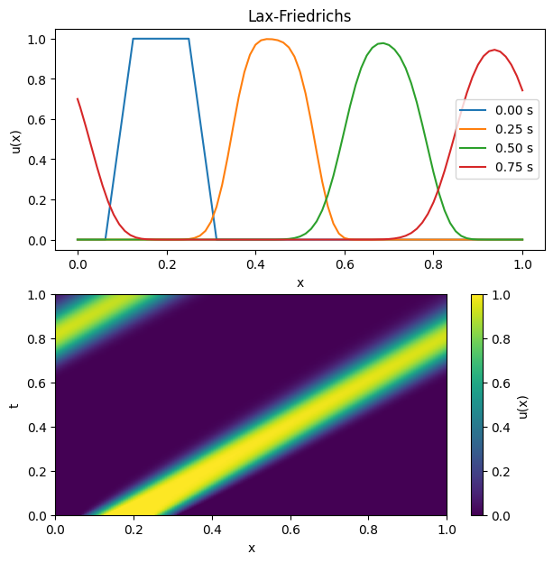

```python
solution_lf = np.zeros((NX, NT))
solution_lf[:, 0] = u0

for tdx in range(0, NT-1):
    for xdx in range(NX):
        lp1 = (xdx + 1) % NX
        lm1 = (xdx - 1) % NX
        solution_lf[xdx, tdx+1] = (
            (solution_lf[lp1, tdx] + solution_lf[lm1, tdx]) / 2
            + dt * (-C * (solution_lf[lp1, tdx] - solution_lf[lm1, tdx])/(2*dx))
        )

plt.figure(figsize=(7, 7))

plt.subplot(2, 1, 1)
for tdx in [0, 50, 100, 150]:
    plt.plot(xarr, solution_lf[:, tdx], label=f"{Tarr[tdx]:.2f} s")
plt.legend()
plt.xlabel("x")
plt.ylabel("u(x)")
plt.title("Lax-Friedrichs")

plt.subplot(2, 1, 2)
plt.imshow(solution_lf.T, origin="lower", aspect="auto", extent=(0, L, 0, T))
plt.colorbar(label="u(x)")
plt.xlabel("x")
plt.ylabel("t")
```

# 5: Lax-Wendroff

## Stability Analysis

Assuming $u_l^n=A_ne^{ikx_l}$: \begin{split} A_{n+1}e^{ikx_l} = A_ne^{ikx_l} - \frac{CFL}{2}(A_ne^{ikx_l} - A_ne^{ik(x_l-\Delta x)}) - \frac{CFL(1-CFL)}{2}A_n(e^{ik(x_l+\Delta x)}-2e^{ikx_l}+e^{ik(x_l-\Delta x)}) \end{split}

This simplifies to: \begin{split} G = \frac{A_{n+1}}{A_n} = 1 - CFL(1-e^{-ik\Delta x}) - \frac{CFL(1-CFL)}{2}(2\cos(k\Delta x)-2) \end{split}

The real part of the above expression is $\text{Re}(G) = 1 + CFL^2(\cos(k\Delta x)-1)$, and the imaginary is $\text{Im}(G) = -CFL\sin(k\Delta x)$.

Therefore: $G = 1 + CFL^2(\cos(k\Delta x)-1) -iCFL\sin(k\Delta x)$.

Expanding this expression to obtain the magnitude $|G|$ for stability analysis results in disgusting math. The easier way is to consider limiting wavenumber cases to simplify the expression first before expanding.

Starting with $k=\pi/2$: \begin{split} \big|G\big|_{k=\pi/2} = (1-CFL)^2 + CFL^2 \leq 1 \\ 1 - CFL^2 + CFL^4 \leq 1 \\ CFL^4 - CFL^2 \leq 0 \\ CFL^2 - 1 \leq 0 \end{split}

This can also be done with $k=\pi$. Both will result in an expression that finds the stability limit to be $CFL \leq 1.0$.

## Modified Equation Analysis

By definition, the Lax-Wendroff scheme on the first-order upwinding method removes the numerical diffusion.  
The only term left is the numerical dispersion term, which is $-\frac{c \Delta x^2}{6}$. This is the same value as for the pure first-order upwinding scheme. In the numerical simulation below, the effect of this dispersion can be seen as the solution starts to "ring" around sharp transitions.

It should be noted that the cancellation of the numerical diffusion by the Lax-Wendroff scheme introduces higher order errors. In this case, additional third order error is introduced, but this does not affect the fact that the scheme is first order accurate in time and second order in space.

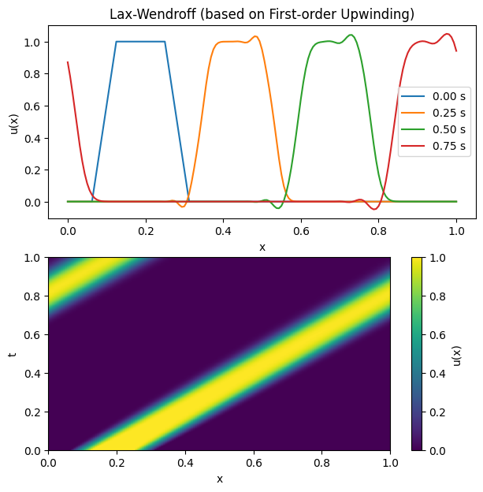

```python
solution_lw = np.zeros((NX, NT))
solution_lw[:, 0] = u0

for tdx in range(0, NT-1):
    for xdx in range(NX):
        lp1 = (xdx + 1) % NX
        lm1 = (xdx - 1) % NX
        solution_lw[xdx, tdx+1] = (
            solution_lw[xdx, tdx]
            + dt * (-C * (solution_lw[xdx, tdx] - solution_lw[lm1, tdx])/dx)
            - CFL * (1 - CFL) / 2 * (solution_lw[lp1, tdx] - 2 * solution_lw[xdx, tdx] + solution_lw[lm1, tdx])
        )

plt.figure(figsize=(7, 7))

plt.subplot(2, 1, 1)
for tdx in [0, 50, 100, 150]:
    plt.plot(xarr, solution_lw[:, tdx], label=f"{Tarr[tdx]:.2f} s")
plt.legend()
plt.xlabel("x")
plt.ylabel("u(x)")
plt.title("Lax-Wendroff (based on First-order Upwinding)")

plt.subplot(2, 1, 2)
plt.imshow(solution_upwind.T, origin="lower", aspect="auto", extent=(0, L, 0, T))
plt.colorbar(label="u(x)")
plt.xlabel("x")
plt.ylabel("t")
```

# 6 Crank-Nicholson

Following the Crank-Nicholson scheme, $u_t + cu_x = 0$ is discretized as: \begin{split} \frac{u_l^{n+1} - u_l^n}{\Delta t} + c \frac{ u_{l+1}^{n+1} - u_{l-1}^{n+1} + u_{l+1}^{n} - u_{l-1}^{n} }{4\Delta x} = 0 \end{split}

This can be rearranged to be: \begin{split} u_l^{n+1} + \frac{CFL}{4}\big(u_{l+1}^{n+1} - u_{l-1}^{n+1}\big) = u_l^n - \frac{CFL}{4}\big(u_{l+1}^{n} - u_{l-1}^{n}\big) \end{split}

## Stability Analysis

Using $u_l^n=A_ne^{ikx_l}$: \begin{split} A_{n+1}e^{ikx_l} + \frac{CFL}{4}\big( A_{n+1}e^{ik(x_l+\Delta x)} - A_{n+1}e^{ik(x_l-\Delta x)} \big) = A_ne^{ikx_l} - \frac{CFL}{4}\big( A_{n}e^{ik(x_l+\Delta x)} - A_{n}e^{ik(x_l-\Delta x)} \big) \end{split}

Divide out $e^{ikx_l}$: \begin{split} A_{n+1} + \frac{CFL}{4}\big( A_{n+1}e^{ik\Delta x} - A_{n+1}e^{-ik\Delta x} \big) = A_n - \frac{CFL}{4}\big( A_{n}e^{ik\Delta x} - A_{n}e^{-ik\Delta x} \big) \end{split}

Using $e^{ik\Delta x} - e^{-ik\Delta x} = 2i\sin(k\Delta x)$, the following expression for amplification ratio can be obtained: \begin{split} \frac{A_{n+1}}{A_n} = \frac{1 - i\frac{CFL}{2}\sin(k\Delta x)}{1 + i\frac{CFL}{2}\sin(k\Delta x)} \end{split}

From this, it can be seen that $\big|\frac{A_{n+1}}{A_n}\big|=1$ always, meaning that the Crank-Nicholson method is unconditionally stable (but right on the edge). It can also be inferred that theoretically there should be no numerical diffusion due to the amplification ratio being 1 exactly.

## Modified Equation Analysis

The same expansions as used previously are still used here. However, the $n+1$ terms must be handled using a 2D Taylor expansion, which is as follows: \begin{split} f(a+h,b+k) = f + hf_a + kf_b + \frac{h^2}{2}f_{aa} + \frac{k^2}{2}f_{bb} + hkf_{ab} + \cdots \end{split} Therefore: \begin{split} u_{l\pm 1}^{n+1} = u \pm \Delta x u_x + \Delta t u_t \pm \Delta x \Delta t u_{xt} + \frac{\Delta x^2}{2}u_{xx} + \frac{\Delta t^2}{2}u_{tt} \pm \frac{\Delta x^3}{6}u_{xxx} + \cdots \end{split}

Starting from the Crank-Nicholson discretization: \begin{split} u_{l+1}^{n+1} - u_{l-1}^{n+1} &= 2\Delta x u_x + \frac{\Delta x^3}{3} u_{xxx} + 2\Delta x \Delta t u_{xt} \\ u_{l+1}^{n} - u_{l-1}^{n} &= 2\Delta x u_x + \frac{\Delta x^3}{3} u_{xxx} \end{split} So the numerator of the fraction is: \begin{split} u_{l+1}^{n+1} - u_{l-1}^{n+1} + u_{l+1}^{n} - u_{l-1}^{n} = 4\Delta x u_x + \frac{2 \Delta x^3}{3}u_{xxx} + 2\Delta x \Delta t u_{xt} \end{split}

Substituting back into the discretized PDE, the modified equation is: \begin{split} \frac{\Delta t u_t + \frac{\Delta t^2}{2}u_{tt}}{\Delta t} + \frac{c}{4\Delta x} \bigg( 4\Delta x u_x + \frac{2 \Delta x^3}{3}u_{xxx} + 2\Delta x \Delta t u_{xt} \bigg) = 0 \\ u_t + \frac{\Delta t}{2}u_{tt} + c \bigg( u_x + \frac{\Delta^2}{6} u_{xxx} + \frac{\Delta t}{2}u_{xt} \bigg) = 0 \end{split}

Since $u_t=-cu_x$, $u_{tt} = -cu_{xt}$. As such: \begin{split} u_t + cu_x = -\frac{c\Delta x^2}{6}u_{xxx} \end{split}

Therefore the numerical dispersion coefficient is $-\frac{c\Delta x^2}{6}$, and there is no numerical diffusion.

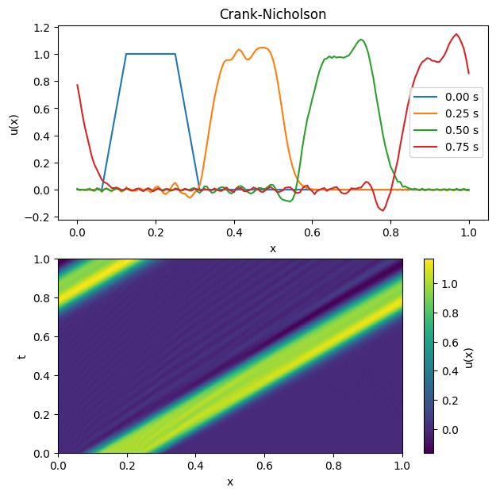

```python
solution_cn = np.zeros((NX, NT))
solution_cn[:, 0] = u0

A = np.zeros((NX, NX))
b = np.zeros(NX)
for tdx in range(1, NT):
    # build coefficient matrix
    for xdx in range(NX):
        lp1 = (xdx + 1) % NX
        lm1 = (xdx - 1) % NX
        A[xdx, lm1] = -CFL/4
        A[xdx, xdx] = 1
        A[xdx, lp1] = CFL/4
        b[xdx] = solution_cn[xdx, tdx-1] - (CFL / 4) * (solution_cn[lp1, tdx-1] - solution_cn[lm1, tdx-1])
    solution_cn[:, tdx] = solverSOR(A, b, relax=0.8)

plt.figure(figsize=(7, 7))

plt.subplot(2, 1, 1)
for tdx in [0, 50, 100, 150]:
    plt.plot(xarr, solution_cn[:, tdx], label=f"{Tarr[tdx]:.2f} s")
plt.legend()
plt.xlabel("x")
plt.ylabel("u(x)")
plt.title("Crank-Nicholson")

plt.subplot(2, 1, 2)
plt.imshow(solution_cn.T, origin="lower", aspect="auto", extent=(0, L, 0, T))
plt.colorbar(label="u(x)")
plt.xlabel("x")
plt.ylabel("t")
```

# 7 Spectral Method

The Fourier transform of a function $f(x)$ is: \begin{split} \mathcal{F}(f(x)) = \hat{f}(k) = \int f(x) e^{-i k x} dx \end{split}

The inverse Fourier transform is: \begin{split} \mathcal{F}^{-1}(\hat{f}(k)) = f(x) = \int \hat{f}(k) e^{i k x} dk \end{split}

Starting with the inverse Fourier transform, the derivative in Fourier space is: \begin{split} \frac{d}{dx}f(x) = \int \hat{f}(k) \frac{d}{dx}e^{ikx} dk = \int ik \hat{f}(k) e^{ikx} dk \end{split}

Taking the Fourier transform of the above, we find that $\frac{d}{dx}\hat{f} = ik \hat{f}(k)$.

For convienience, the FFT module in NumPy will be used to perform the Fourier transform and obtain the wavenumbers.

An RK4 integrator is used to help with stability.

Note that even though mathematically the FFT spectral method is exact, in practice due to truncated Fourier series there is frequency truncation. The loss of the high frequency information results in "ringing" (Gibbs phenomenon) near sharp corners. It may look like dispersion but is not caused by uneven wavespeeds.

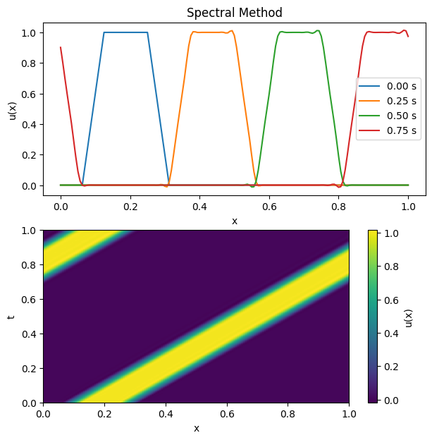

```python
solution_spectral = np.zeros((NX, NT))
solution_spectral[:, 0] = u0

k = np.fft.fftfreq(NX, d=dx/(2*np.pi))

fn_u_x = lambda x: np.fft.ifft(1j * k * np.fft.fft(x)).real
fn_u_t = lambda x: -C * fn_u_x(x)

for tdx in range(0, NT-1):
    k1 = fn_u_t(solution_spectral[:, tdx])
    k2 = fn_u_t(solution_spectral[:, tdx] + k1 * dt / 2)
    k3 = fn_u_t(solution_spectral[:, tdx] + k2 * dt / 2)
    k4 = fn_u_t(solution_spectral[:, tdx] + k3 * dt)
    solution_spectral[:, tdx + 1] = solution_spectral[:, tdx] + (k1 + 2*k2 + 2*k3 + k4) * dt / 6

plt.figure(figsize=(7, 7))

plt.subplot(2, 1, 1)
for tdx in [0, 50, 100, 150]:
    plt.plot(xarr, solution_spectral[:, tdx], label=f"{Tarr[tdx]:.2f} s")
plt.legend()
plt.xlabel("x")
plt.ylabel("u(x)")
plt.title("Spectral Method")

plt.subplot(2, 1, 2)
plt.imshow(solution_spectral.T, origin="lower", aspect="auto", extent=(0, L, 0, T))
plt.colorbar(label="u(x)")
plt.xlabel("x")
plt.ylabel("t")
```